# Projet Fierthé

KOUASSI KONAN LEGER

2025-06-24

# Objectif : Formuler des propositions claires pour la valorisation durable du thé en France

## Phase 1 – Prise en main et cadrage

## Objectifs

- Comprendre le contexte du projet et les enjeux de la filière théicole durable
- Se familiariser avec la base de données **MINTEL GNPD** et les outils

## Tâches

- Lecture du projet Fierthé, documents internes et publications liées
- Prise en main de la base **MINTEL** (structure, variables, type de données)
- Rencontre avec le tuteur

## Analyses univariées

```r
# Importation des packages nécessaires
library(tidyverse)    # Inclut dplyr, tidyr, ggplot2, stringr
library(readxl)
library(lubridate)
library(wordcloud)
library(tidytext)
library(scales)
library(tm)
library(forcats)

# Nettoyage de l'environnement
rm(list = ls())

# Importation des données
gnpd_brut <- read_excel("GNPD_tea.xlsx")

# Analyse globale de la base de données
glimpse(gnpd_brut)
```

```
## Rows: 99,608
## Columns: 33
## $ `Record ID`                   <dbl> 12811782, 12811806, 12811808, 12824062, …
## $ `Date Published`              <dttm> 2025-05-02, 2025-05-02, 2025-05-02, 202…
## $ `Format Type`                 <chr> NA, "Liquid", "Liquid", NA, NA, NA, "Loo…
## $ `Number of Variants`          <dbl> 1, 1, 1, 2, 2, 1, 1, 1, 1, 1, 4, 4, 4, 1…
## $ `Product Source`              <chr> "Physical Product", "Physical Product", …
## $ `Ingredients (Standard form)` <chr> "Tuna, Tuna Extract, technological addit…
## $ Company                       <chr> "Thai Inaba Foods", "Biogroupe", "KQ", "…
## $ Market                        <chr> "Italy", "Italy", "Italy", "Singapore", …
## $ `Location of Manufacture`     <chr> "Thailand", NA, NA, "Taiwan, China", "Ta…
## $ Brand                         <chr> "Ciao Churu Pops", "Karma Kombucha", "Ko…
## $ `Launch Type`                 <chr> "New Product", "New Variety/Range Extens…
## $ Product                       <chr> "Tuna Recipe Cat Treat", "Sugar-Free Spa…
## $ `Price per 100 g/ml in Euros` <chr> "5.42", "0.93", "1.03", "0.38", "0.38", …
```

[output cut: 20 more lines]

```r
# Conversion des variables en format approprié
gnpd_brut <- gnpd_brut %>%
  mutate(
    `Price per 100 g/ml in Euros` = as.numeric(`Price per 100 g/ml in Euros`),
    `Price in US Dollars` = as.numeric(`Price in US Dollars`),
    `Price in Euros` = as.numeric(`Price in Euros`),
    `Unit Pack Size (ml/g)` = as.numeric(`Unit Pack Size (ml/g)`),
    `Alcohol By Volume (%)` = as.numeric(`Alcohol By Volume (%)`),
    `Date Published` = as.Date(`Date Published`)
  )

# Élimination des variables non pertinentes
gnpd <- gnpd_brut %>%
  select(-c(`Record ID`,`Record hyperlink`,`Bar Code`,`Alcohol By Volume (%)`,
            `Allergens / Warnings`))

# Transformation des colonnes
gnpd <- gnpd %>%
  mutate(
    price_per_100 = as.numeric(`Price per 100 g/ml in Euros`),
    year = year(`Date Published`),
    month = floor_date(`Date Published`, "month")
  )

# Filtrage des données aberrantes
total_lignes <- nrow(gnpd)

gnpd_filtre <- gnpd %>%
  filter(`Unit Pack Size (ml/g)` >= 2,
         `Unit Pack Size (ml/g)` <= 5000)

proportion_conservee <- nrow(gnpd_filtre) / total_lignes

# Affichage de la proportion conservée
proportion_conservee
```

```
## [1] 0.9045358
```

```r
gnpd <- gnpd_filtre
```

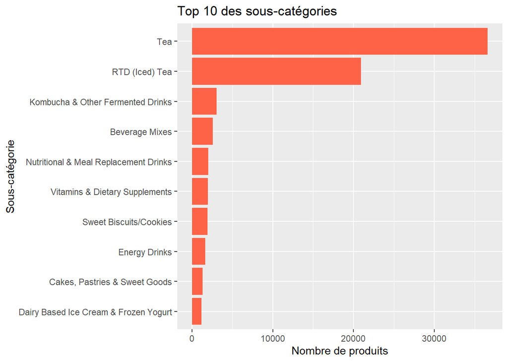

```r
# Sous-categorie
gnpd %>%
  count(`Sub-Category`, sort = TRUE) %>%
  slice_max(n, n = 10) %>%
  ggplot(aes(x = reorder(`Sub-Category`, n), y = n)) +
  geom_col(fill = "tomato") +
  coord_flip() +
  labs(title = "Top 10 des sous-catégories",
       x = "Sous-catégorie",
       y = "Nombre de produits")
```

## Analyse de la variable “Positioning Claims” Je l’hypothese selon laquelle cette variable est suceptible d’influencer non seulement le prix mais aussi le choix des consommateurs.

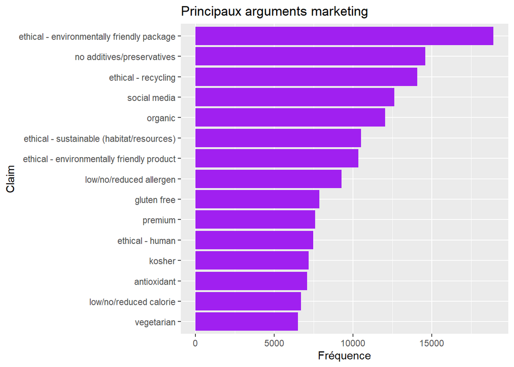

```r
# Extraction des claims individuels
claims <- gnpd %>%
  filter(!is.na(`Positioning Claims`)) %>%
  unnest_tokens(claim, `Positioning Claims`, token = "regex",
                pattern = ",\\s*") %>%
  count(claim, sort = TRUE)

# Barplot des claims les plus fréquents
claims %>%
  slice_max(n, n = 15) %>%
  ggplot(aes(x = reorder(claim, n), y = n)) +
  geom_col(fill = "purple") +
  coord_flip() +
  labs(title = "Principaux arguments marketing", x = "Claim", y = "Fréquence")
```

Nous pouvons contacter sur ce graphique les effets dominents des differents produits. Essayons de projetter les mots dominents de issu de cette variable qui peut etre par la suite peut nous aider à avoir certaines combinansons qui peuvent aider à avoir un titre de produit de haute qualité.

# Nuage de mot de la variable “Positioning claims”

Je me suis basé sur les exemple de ce lien : https://www.sthda.com/french/wiki/text-mining-et-nuage-de-mots-avec-le-logiciel-r-5-etapes-simples-a-savoir

```r
library(tm)
set.seed(123)
text_corpus <- Corpus(VectorSource(gnpd$`Positioning Claims`))
toSpace <- content_transformer(function (x , pattern ) gsub(pattern, " ", x))

text_corpus <- tm_map(text_corpus, toSpace, "/")
text_corpus <- tm_map(text_corpus, toSpace, "-")
text_corpus <- tm_map(text_corpus, content_transformer(tolower))
text_corpus <- tm_map(text_corpus, removePunctuation)
text_corpus <- tm_map(text_corpus,
                      function(x)removeWords(x,stopwords(kind = "english")))
```

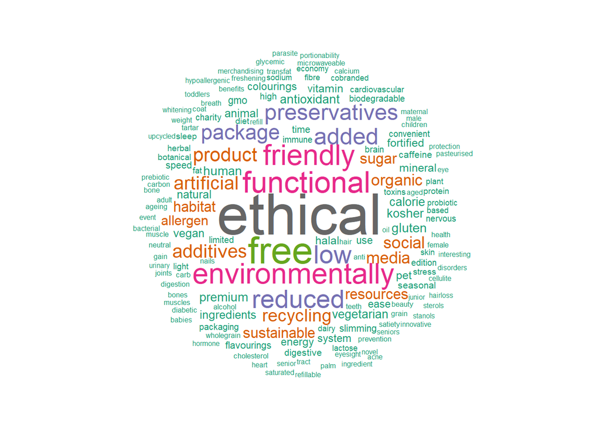

```r
wordcloud(text_corpus, colors = brewer.pal(8, "Dark2"),
          rot.per=0, random.order = F)
```

```r
dtm <- TermDocumentMatrix(text_corpus)
m <- as.matrix(dtm)
v <- sort(rowSums(m),decreasing=TRUE)
d <- data.frame(word = names(v),freq=v)
head(d, 10)
```

```
##                            word  freq
## ethical                 ethical 68145
## free                       free 41161
## functional           functional 31101
## environmentally environmentally 29235
## friendly               friendly 29235
## low                         low 24814
## reduced                 reduced 24814
## added                     added 21870
## preservatives     preservatives 20656
## package                 package 18895
```